# Taller 2: Análisis ANOVA-MANOVA

MRamirez, JRojas, LRomero,ADarghan

6/24/2020

# Introducción

A continuación se presenta una serie de ejercicios propuesto que permitiran interiorizar el análisis de datos multivariados utilizandos las técnicas ANOVA y MANOVA. Estos ejercicios hacen parte del contenido académico desarrollado por el profesor Aquiles Enrique Darghan Contreras referente a la asignatura de Métodos Multivariados.

Previo a la solución de los ejercicios es necesario instalar y cargar las siguientes librerías.

```r
library(readxl)
library(ggplot2)
library(mvShapiroTest)
library(biotools)
library(outliers)
library(ICSNP)
library(tidyverse)
```

## Datos

Los ejercicios mostrados son desarrollados a partir de los siguientes datos correspondientes a una toma realizada con un espectroradiómetro en los anchos de bandas correspondientes a 560 *nm* y 720 *nm* de las especies *SS*, *JL* y *LP*

| D_560nm | D_720nm | Species |
| --- | --- | --- |
| 9.33 | 19.14 | SS |
| 8.74 | 19.55 | SS |
| 9.31 | 19.24 | SS |
| 8.27 | 16.37 | SS |
| 10.22 | 25 | SS |
| 10.13 | 25.32 | SS |
| 10.42 | 27.12 | SS |
| 10.62 | 26.28 | SS |
| 15.25 | 38.89 | SS |
| 16.22 | 36.67 | SS |
| 17.24 | 40.74 | SS |
| 12.77 | 67.5 | SS |
| 12.07 | 33.03 | JL |
| 11.03 | 32.37 | JL |
| 12.48 | 31.31 | JL |
| 12.12 | 33.33 | JL |
| 15.38 | 40 | JL |
| 14.21 | 40.48 | JL |
| 9.69 | 33.9 | JL |
| 14.35 | 40.15 | JL |
| 38.71 | 77.14 | JL |
| 44.74 | 78.57 | JL |
| 36.67 | 71.43 | JL |
| 37.21 | 45 | JL |
| 8.73 | 23.27 | LP |
| 7.94 | 20.87 | LP |
| 8.37 | 22.16 | LP |
| 7.86 | 21.78 | LP |
| 8.45 | 26.32 | LP |
| 6.79 | 22.73 | LP |
| 8.34 | 26.67 | LP |
| 7.54 | 24.87 | LP |
| 14.04 | 44.44 | LP |
| 13.51 | 37.93 | LP |
| 13.33 | 37.93 | LP |
| 12.77 | 60.87 | LP |

Los datos se encuentran disponibles en un archivo de [google sheets](https://docs.google.com/spreadsheets/d/1KeSKTZRl8or_yGPC7_876nhyAQlxqjK3EC9UVl8n4yc/edit?usp=sharing) para quien desee realizar los mismos ejercicios presentados.

Como primer paso los datos son cargados a la variable denominada *Reflectancia*

```r
Reflectancia <- read_excel("Datos_ANOVA_MANOVA.xlsx")
```

# Punto 1: MANOVA

Para el análisis se realizan las gráficas para cada longitud de onda y un gráfico de dispersión que muestre la relación de las dos:

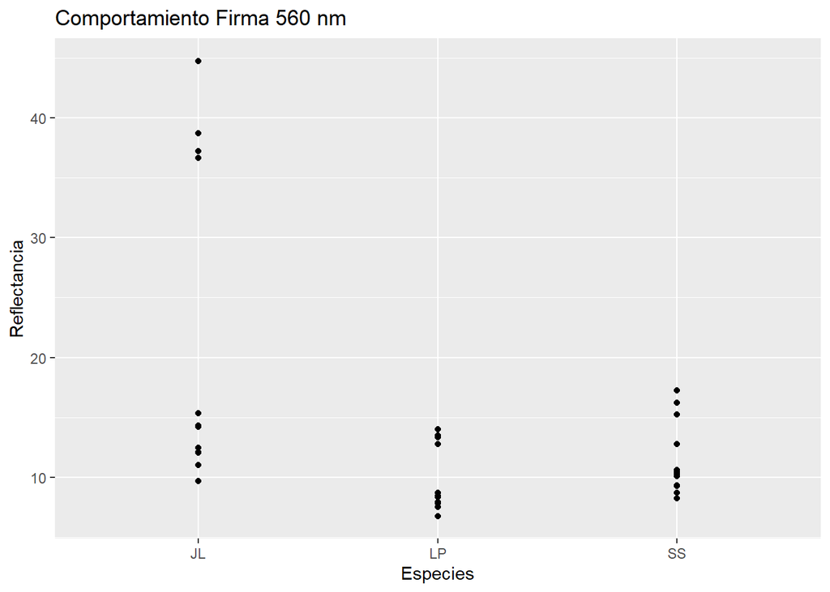

```r
ggplot(data=Reflectancia, aes(Species,D_560nm)) + geom_point() + ggtitle("Comportamiento Firma 560 nm") + xlab("Especies") + ylab("Reflectancia")
```

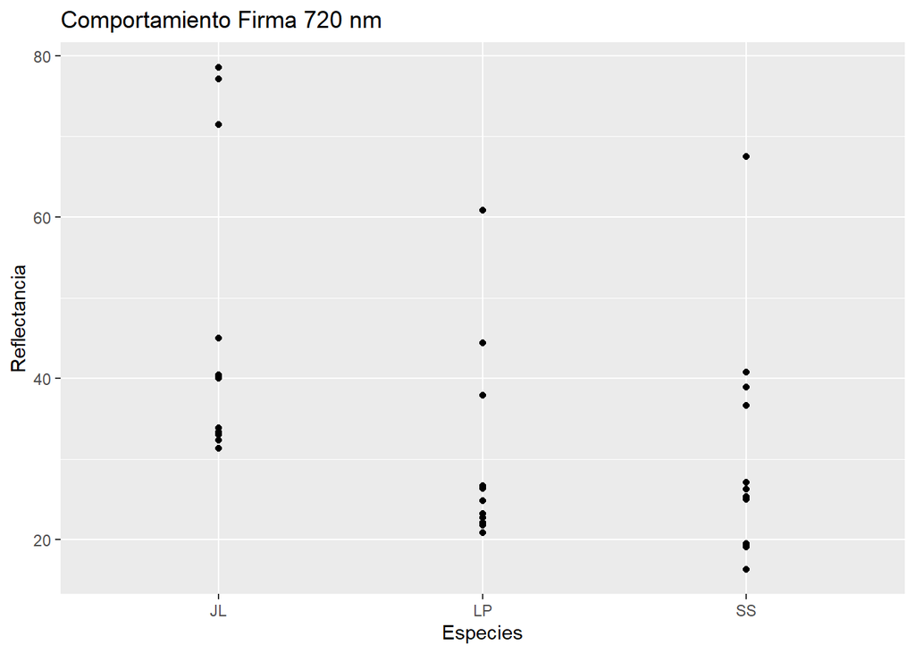

```r
ggplot(data=Reflectancia, aes(Species,D_720nm)) + geom_point() + ggtitle("Comportamiento Firma 720 nm") + xlab("Especies") + ylab("Reflectancia")
```

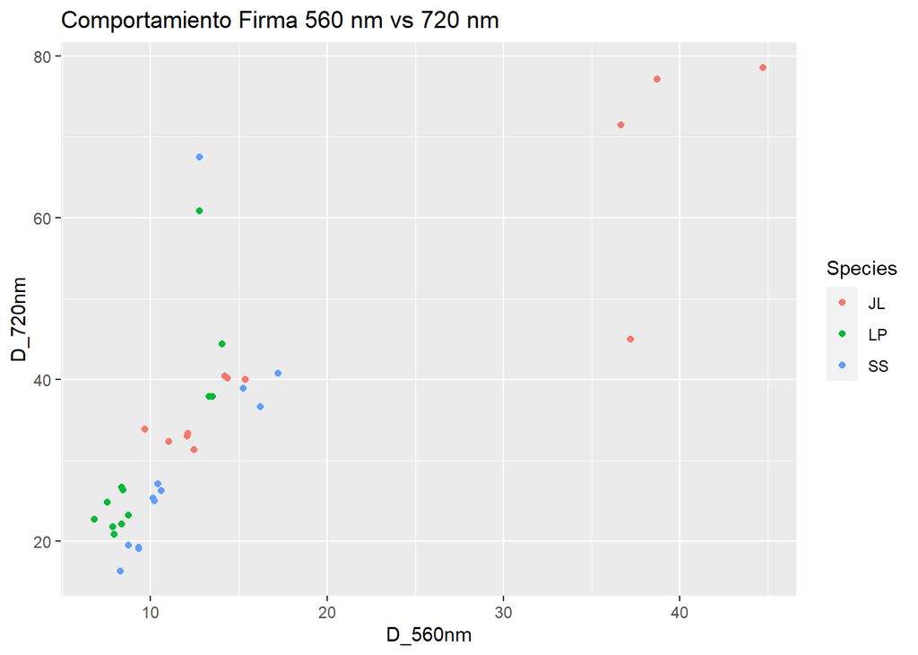

```r
ggplot(data=Reflectancia, aes(D_560nm,D_720nm, color=Species)) + geom_point() + ggtitle("Comportamiento Firma 560 nm vs 720 nm")
```

Se procede a realizar el análisis MANOVA y se presenta un resumen del mismo con la hipotesis con el test de *Wilks*

```r
MN=manova(cbind(Reflectancia$D_560nm,Reflectancia$D_720nm) ~ Reflectancia$Species)
MN
```

```
## Call:
##    manova(cbind(Reflectancia$D_560nm, Reflectancia$D_720nm) ~ Reflectancia$Species)
##
## Terms:
##                 Reflectancia$Species Residuals
## resp 1                       965.181  2147.714
## resp 2                      2026.856  7536.997
## Deg. of Freedom                    2        33
##
## Residual standard errors: 8.067357 15.11271
## Estimated effects may be unbalanced
```

```r
summary(MN,test="Wilks")
```

```
##                      Df   Wilks approx F num Df den Df Pr(>F)
## Reflectancia$Species  2 0.67704   3.4452      4     64  0.013 *
## Residuals            33
## ---
## Signif. codes:  0 '***' 0.001 '**' 0.01 '*' 0.05 '.' 0.1 ' ' 1
```

# Punto 2: ANOVA

```r
AV1=aov(Reflectancia$D_560nm ~ Reflectancia$Species)
summary(AV1)
```

```
##                      Df Sum Sq Mean Sq F value  Pr(>F)
## Reflectancia$Species  2  965.2   482.6   7.415 0.00219 **
## Residuals            33 2147.7    65.1
## ---
## Signif. codes:  0 '***' 0.001 '**' 0.01 '*' 0.05 '.' 0.1 ' ' 1
```

```r
AV2=aov(Reflectancia$D_720nm ~ Reflectancia$Species)
summary(AV2)
```

```
##                      Df Sum Sq Mean Sq F value Pr(>F)
## Reflectancia$Species  2   2027  1013.4   4.437 0.0196 *
## Residuals            33   7537   228.4
## ---
## Signif. codes:  0 '***' 0.001 '**' 0.01 '*' 0.05 '.' 0.1 ' ' 1
```

# Punto 3: Test de Correlación

A continuación es realizado el test de correlación de *Pearson*

```r
cor.test(Reflectancia$D_560nm,Reflectancia$D_720nm)
```

```
##
##  Pearson's product-moment correlation
##
## data:  Reflectancia$D_560nm and Reflectancia$D_720nm
## t = 8.144, df = 34, p-value = 1.691e-09
## alternative hypothesis: true correlation is not equal to 0
## 95 percent confidence interval:
##  0.6611588 0.9009499
## sample estimates:
##       cor
## 0.8130816
```

Observese que si existe relación lineal entre las dos variables, por lo tanto no se puede asumir que sea nula la correlación.

# Punto 4: Normalidad univariada

A continuación es realizado el test de *Shapiro-Wilk* para cada una de las respuestas

```r
shapiro.test(Reflectancia$D_560nm)
```

```
##
##  Shapiro-Wilk normality test
##
## data:  Reflectancia$D_560nm
## W = 0.64673, p-value = 4.538e-08
```

```r
shapiro.test(Reflectancia$D_720nm)
```

```
##
##  Shapiro-Wilk normality test
##
## data:  Reflectancia$D_720nm
## W = 0.84251, p-value = 0.0001286
```

No se puede asumir normalidad en alguna de las dos variables.

# Punto 5: Normalidad multivariada

A continuación es realizado el test multivariado de *Shapiro-Wilk*

```r
mvShapiro.Test(as.matrix(Reflectancia[,1:2]))
```

```
##
##  Generalized Shapiro-Wilk test for Multivariate Normality by
##  Villasenor-Alva and Gonzalez-Estrada
##
## data:  as.matrix(Reflectancia[, 1:2])
## MVW = 0.81281, p-value = 3.948e-08
```

No se puede asumir normalidad multivariada.

# Punto 6: Igualdad de Varianza Univariante

A continuación es realizado el test multivariado de *Barlett*

```r
bartlett.test(Reflectancia$D_560nm ~ Reflectancia$Species)
```

```
##
##  Bartlett test of homogeneity of variances
##
## data:  Reflectancia$D_560nm by Reflectancia$Species
## Bartlett's K-squared = 32.714, df = 2, p-value = 7.876e-08
```

```r
bartlett.test(Reflectancia$D_720nm ~ Reflectancia$Species)
```

```
##
##  Bartlett test of homogeneity of variances
##
## data:  Reflectancia$D_720nm by Reflectancia$Species
## Bartlett's K-squared = 1.7462, df = 2, p-value = 0.4177
```

# Punto 7: Igualdad de matrices de varianza y covarianza

Para evaluar la igualdad de la matriz de varianza y covarianza fue realizado el test M de *Box*

```r
boxM(as.matrix(Reflectancia[,-3]),as.matrix(Reflectancia$Species))
```

```
##
##  Box's M-test for Homogeneity of Covariance Matrices
##
## data:  as.matrix(Reflectancia[, -3])
## Chi-Sq (approx.) = 41.969, df = 6, p-value = 1.865e-07
```

Concluyendo: no es posible asumir que las matrices de varianza y covarianza por cada una de las especies son iguales.

# Punto 8: Outliers univariados

Se realiza un gráfico box-plot para cada uno de los valores de longitud de onda y también fue realizada la prueba de *Dixon* que también hace la identificación de los valores atípicos:

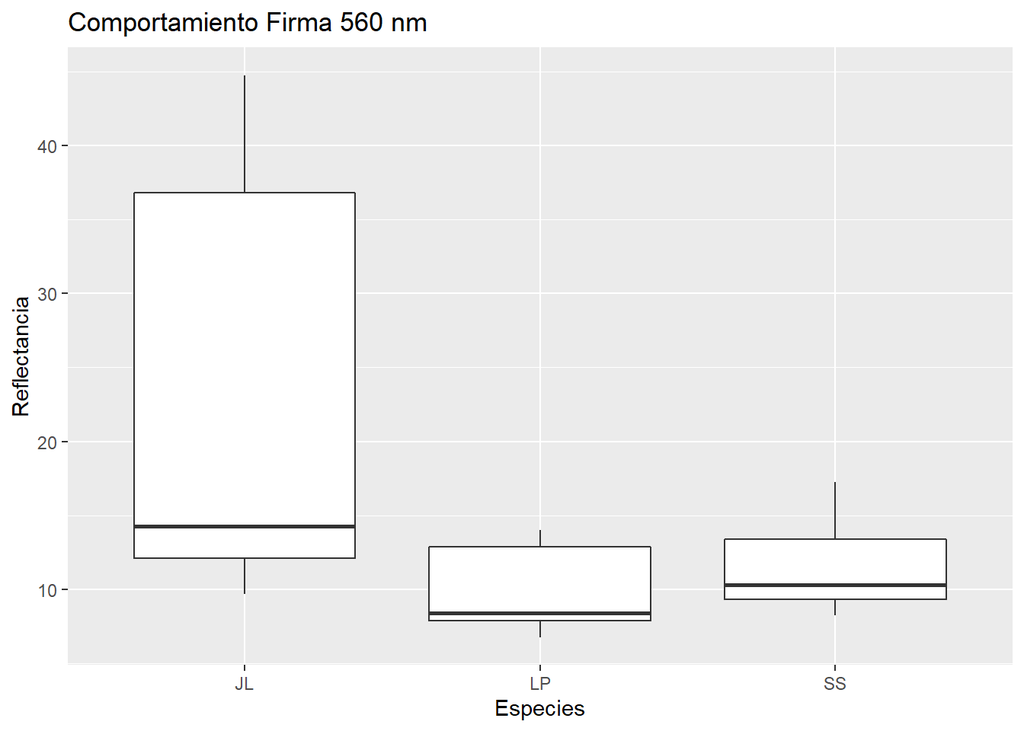

```r
#Gráficas Box-clot

ggplot(data=Reflectancia, aes(Species,D_560nm)) + geom_boxplot() + ggtitle("Comportamiento Firma 560 nm") + xlab("Especies") + ylab("Reflectancia")
```

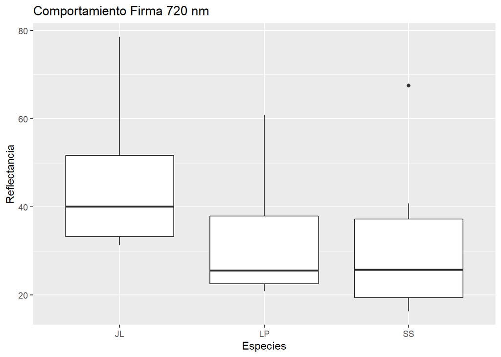

```r
ggplot(data=Reflectancia, aes(Species,D_720nm)) + geom_boxplot() + ggtitle("Comportamiento Firma 720 nm") + xlab("Especies") + ylab("Reflectancia")
```

```r
# Prueba de Dixon

dixon.test(sample(Reflectancia$D_560nm, size=30))
```

```
##
##  Dixon test for outliers
##
## data:  sample(Reflectancia$D_560nm, size = 30)
## Q = 0.20418, p-value = 0.8265
## alternative hypothesis: highest value 44.74 is an outlier
```

```r
dixon.test(sample(Reflectancia$D_720nm, size=30))
```

```
##
##  Dixon test for outliers
##
## data:  sample(Reflectancia$D_720nm, size = 30)
## Q = 0.12034, p-value = 0.5587
## alternative hypothesis: highest value 78.57 is an outlier
```

# Punto 9: Outliers multivariados

Para observar los valores atípicos multivariados es realizado a partir del estadístico T$^2$ y comparado con el percentil que este posee con la distribución chi cuadrado.

```r
vec.medias=apply(Reflectancia[,1:2],2,mean);vec.medias
```

```
##  D_560nm  D_720nm
## 14.30139 35.78806
```

```r
T2=c()
for(j in 1:dim(Reflectancia)[1]){
  T2[j]=c((t(t(Reflectancia[j,1:2])-(vec.medias)))%*%solve(var(Reflectancia[,1:2]))%*%as.matrix(t(Reflectancia[j,1:2])-(vec.medias)))
}
T2
```

```
##  [1]  1.26541020  1.09383567  1.24128875  1.67375718  0.45417223  0.41656430
##  [7]  0.27561128  0.34847917  0.04318851  0.07844282  0.10339451 12.43210949
## [13]  0.05790637  0.13704612  0.07555811  0.05807567  0.09033585  0.25119830
## [19]  0.47601009  0.19901130  7.16415107 10.42111846  5.77865326 11.83215879
## [25]  0.57530618  0.82479717  0.68473177  0.71821599  0.39872455  0.69415980
## [31]  0.40375328  0.53175909  0.88021407  0.12249645  0.14489054  8.05347359
```

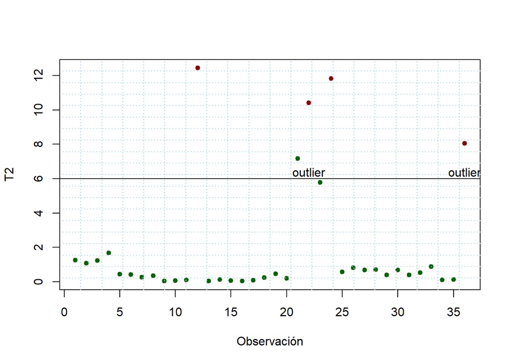

```r
LS=qchisq(0.95,df=dim(Reflectancia)-1)
colores=ifelse(T2>LS,"darkred","darkgreen")
plot(T2,col=colores,pch=19,cex=0.85,xlab="Observación")
grid(20,20,col="lightblue")
abline(h=LS)
etiquetas=which(T2>LS)
text(etiquetas,c(LS)+0.4,"outlier")
```

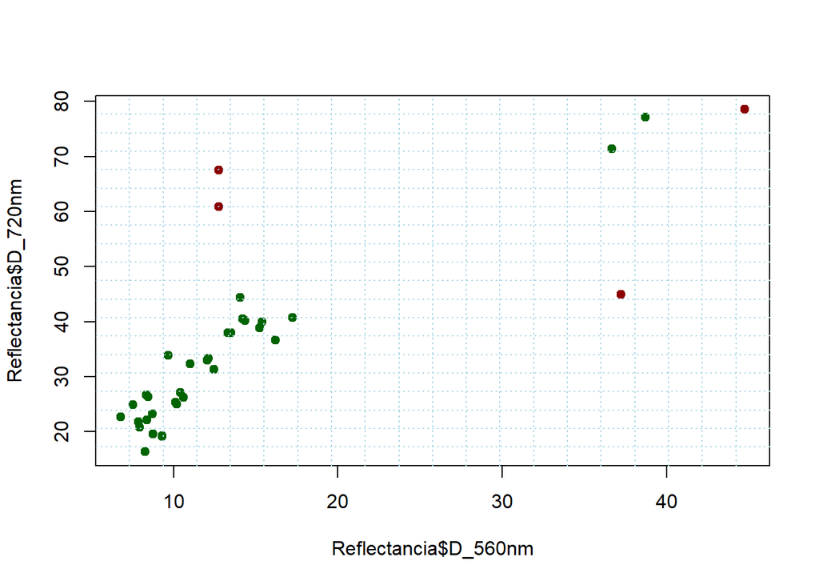

```r
plot(Reflectancia$D_560nm,Reflectancia$D_720nm,pch=19,col=colores)
grid(20,20,col="lightblue")
```

# Punto 10: Comparación de medias por cada respuesta

```r
# ESPECIE SS - JL

data.a <- filter(Reflectancia, Species != "LP")
PruebaH21 <- HotellingsT2(as.matrix(data.a[,1:2])~as.matrix(data.a[,3]), mu = c(0,0)) ##
PruebaH21
```

```
##
##  Hotelling's two sample T2-test
##
## data:  as.matrix(data.a[, 1:2]) by as.matrix(data.a[, 3])
## T.2 = 3.2938, df1 = 2, df2 = 21, p-value = 0.05699
## alternative hypothesis: true location difference is not equal to c(0,0)
```

```r
# ESPECIE SS - LP

data.b <- filter(Reflectancia, Species != "JL")
PruebaH22 <- HotellingsT2(as.matrix(data.b[,1:2])~as.matrix(data.b[,3]), mu = c(0,0)) ##
PruebaH22
```

```
##
##  Hotelling's two sample T2-test
##
## data:  as.matrix(data.b[, 1:2]) by as.matrix(data.b[, 3])
## T.2 = 2.4676, df1 = 2, df2 = 21, p-value = 0.109
## alternative hypothesis: true location difference is not equal to c(0,0)
```

```r
# ESPECIE JL - LP

data.c <- filter(Reflectancia, Species != "SS")
PruebaH23 <- HotellingsT2(as.matrix(data.c[,1:2])~as.matrix(data.c[,3]), mu = c(0,0)) ##
PruebaH23
```

```
##
##  Hotelling's two sample T2-test
##
## data:  as.matrix(data.c[, 1:2]) by as.matrix(data.c[, 3])
## T.2 = 4.2569, df1 = 2, df2 = 21, p-value = 0.02806
## alternative hypothesis: true location difference is not equal to c(0,0)
```

De acuerdo a la prueba T$^2$ de Hotelling, bajo un nivel de confianza del 95% no se puede asumir que el vector de medias de las especies JL y LP son iguales, mientras que las especies SS y LP si. No obstante, se debe señalar que la prueba indica que las medias de las especies SS y JL puede decirse que son iguales, pero el p-valor del test se acerca sensiblemente y por consiguiente se debe analizar con más detalle este aspecto.

# Punto 11: Intervalos simultaneos MANOVA.

Se procede a realizar la determinación de los intervalos simultaneos de confianza para cada una de las combinaciones posibles de las especies:

```r
# DATOS POR CADA ESPECIE

data.SS <- filter(Reflectancia, Species == "SS")
data.JL <- filter(Reflectancia, Species == "JL")
data.LP <- filter(Reflectancia, Species == "LP")

# VECTOR DE MEDIAS

vec.mediasSS=apply(data.SS[,1:2],2,mean);vec.mediasSS
```

```
##  D_560nm  D_720nm
## 11.54333 30.15167
```

```r
vec.mediasJL=apply(data.JL[,1:2],2,mean);vec.mediasJL
```

```
## D_560nm D_720nm
## 21.5550 46.3925
```

```r
vec.mediasLP=apply(data.LP[,1:2],2,mean);vec.mediasLP
```

```
##   D_560nm   D_720nm
##  9.805833 30.820000
```

```r
# MATRICES DE COVARIANZA

varSS=var(data.SS[,1:2]); varSS
```

```
##           D_560nm   D_720nm
## D_560nm  9.444588  28.47334
## D_720nm 28.473339 203.87040
```

```r
varJL=var(data.JL[,1:2]); varJL
```

```
##          D_560nm  D_720nm
## D_560nm 178.3878 221.8819
## D_720nm 221.8819 332.1606
```

```r
varLP=var(data.LP[,1:2]); varLP
```

```
##           D_560nm   D_720nm
## D_560nm  7.414354  27.71932
## D_720nm 27.719318 149.15058
```

```r
# PARÁMETROS DEL INTERVALO

vec.mediasTotal=apply(Reflectancia[,1:2],2,mean);vec.mediasTotal
```

```
##  D_560nm  D_720nm
## 14.30139 35.78806
```

```r
t1=vec.mediasSS-vec.mediasTotal
t2=vec.mediasJL-vec.mediasTotal
t3=vec.mediasLP-vec.mediasTotal
W=(dim(data.SS)[1]-1)*varSS+(dim(data.JL)[1]-1)*varJL+(dim(data.LP)[1]-1)*varLP; W
```

```
##          D_560nm  D_720nm
## D_560nm 2147.714 3058.820
## D_720nm 3058.820 7536.997
```

```r
pt=qt((0.05/(2*3*(3-1))),df=(dim(Reflectancia)[1]-3)); pt
```

```
## [1] -2.806761
```

```r
# INTERVALO ENTRE SS Y JL A UNA LONGITUD DE ONDA DE 560 nm

t.SS_JL.560=t1[1]-t2[1]
p.SS_JL.560=sqrt(((1/dim(data.SS)[1])+(1/dim(data.JL)[1]))*(W[1,1]/(dim(Reflectancia)[1]-3)))
(limsup.SS_JL.560=t.SS_JL.560+p.SS_JL.560)
```

```
##   D_560nm
## -6.718182
```

```r
(liminf.SS_JL.560=t.SS_JL.560-p.SS_JL.560)
```

```
##   D_560nm
## -13.30515
```

```r
# INTERVALO ENTRE SS Y JL A UNA LONGITUD DE ONDA DE 720 nm

t.SS_JL.720=t1[2]-t2[2]
p.SS_JL.720=sqrt(((1/dim(data.SS)[1])+(1/dim(data.JL)[1]))*(W[2,2]/(dim(Reflectancia)[1]-3)))
(limsup.SS_JL.720=t.SS_JL.720+p.SS_JL.720)
```

```
##  D_720nm
## -10.0711
```

```r
(liminf.SS_JL.720=t.SS_JL.720-p.SS_JL.720)
```

```
##   D_720nm
## -22.41057
```

```r
# INTERVALO ENTRE SS Y LP A UNA LONGITUD DE ONDA DE 560 nm

t.SS_LP.560=t1[1]-t3[1]
p.SS_LP.560=sqrt(((1/dim(data.SS)[1])+(1/dim(data.LP)[1]))*(W[1,1]/(dim(Reflectancia)[1]-3)))
(limsup.SS_LP.560=t.SS_LP.560+p.SS_LP.560)
```

```
##  D_560nm
## 5.030985
```

```r
(liminf.SS_LP.560=t.SS_LP.560-p.SS_LP.560)
```

```
##   D_560nm
## -1.555985
```

```r
# INTERVALO ENTRE SS Y LP A UNA LONGITUD DE ONDA DE 720 nm

t.SS_LP.720=t1[2]-t3[2]
p.SS_LP.720=sqrt(((1/dim(data.SS)[1])+(1/dim(data.LP)[1]))*(W[2,2]/(dim(Reflectancia)[1]-3)))
(limsup.SS_LP.720=t.SS_LP.720+p.SS_LP.720)
```

```
##  D_720nm
## 5.501403
```

```r
(liminf.SS_LP.720=t.SS_LP.720-p.SS_LP.720)
```

```
##   D_720nm
## -6.838069
```

```r
# INTERVALO ENTRE JL Y LP A UNA LONGITUD DE ONDA DE 560 nm

t.JL_LP.560=t2[1]-t3[1]
p.JL_LP.560=sqrt(((1/dim(data.JL)[1])+(1/dim(data.LP)[1]))*(W[1,1]/(dim(Reflectancia)[1]-3)))
(limsup.JL_LP.560=t.JL_LP.560+p.JL_LP.560)
```

```
##  D_560nm
## 15.04265
```

```r
(liminf.JL_LP.560=t.JL_LP.560-p.JL_LP.560)
```

```
##  D_560nm
## 8.455682
```

```r
# INTERVALO ENTRE JL Y LP A UNA LONGITUD DE ONDA DE 720 nm

t.JL_LP.720=t2[2]-t3[2]
p.JL_LP.720=sqrt(((1/dim(data.JL)[1])+(1/dim(data.LP)[1]))*(W[2,2]/(dim(Reflectancia)[1]-3)))
(limsup.JL_LP.720=t.JL_LP.720+p.JL_LP.720)
```

```
##  D_720nm
## 21.74224
```

```r
(liminf.JL_LP.720=t.JL_LP.720-p.JL_LP.720)
```

```
##  D_720nm
## 9.402764
```

A partir de los resultados se puede indicar que para las especies SS y JL, JL y LP son diferentes para las dos longitudes de onda mientras que esta característica es contraría para las especies SS y LP, es decir que estos dos sensores no poseen diferencias estadísticas en las dos longitudes de onda.

# Punto 12: Inclusión de variables de bloque localidades.

Se muestra a continuación el procedimiento para añadir un nuevo factor de bloqueo con el propósito de determinar si este mismo es capaz de cambiar las conclusiones tomadas en los análisis previos.

```r
loc=c(rep("L1",6),rep("L2",6)) #Vector de bloqueo
Reflectancia_loc=cbind(Reflectancia,loc)
Reflect_join=cbind(Reflectancia$D_560nm,Reflectancia$D_720nm)

modM2=manova(Reflect_join~Reflectancia_loc$Species+Reflectancia_loc$loc)
summary(modM2, test="Wilks")
```

```
##                          Df   Wilks approx F num Df den Df    Pr(>F)
## Reflectancia_loc$Species  2 0.57824   4.8834      4     62 0.0017312 **
## Reflectancia_loc$loc      1 0.55955  12.2008      2     31 0.0001235 ***
## Residuals                32
## ---
## Signif. codes:  0 '***' 0.001 '**' 0.01 '*' 0.05 '.' 0.1 ' ' 1
```

El modelo indica que hay diferencias entre los grupos, lo cual también se evidenció en los análisis previos, es decir que la inclusión de esta variable no cambia de forma significativa las conclusiones realizadas previamente.

# Bibliografía

*Richard A. Johnson & Dean W. Wichern (2014). Comparisons of Several Multivariate Means. In: Richard A. Johnson & Dean W. Applied Multivariate Statistical Analysis. Pearson Prentice Hall. 775 pp.*

*Douglas C. Montgomery (2004). Design and Analysis of Experiments. Editorial Limusa S. A. 692 pp.*